# R俱乐部

## day05

### 杜 月新

### RStudio

### 2020/11/09

##day05 相关关系

辅助教材:「Rで楽しむ統計」＆chapter8

# 准备

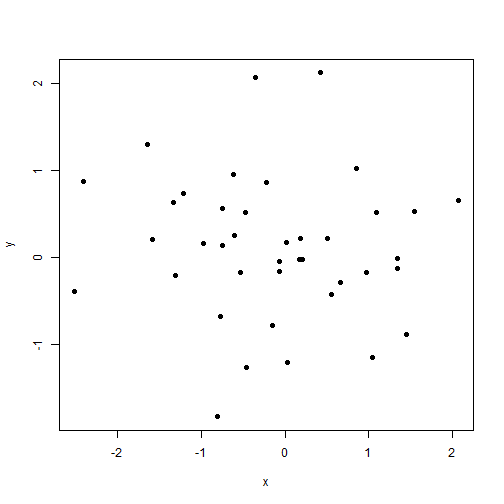

```r
x=rnorm(40)
y=rnorm(40)
plot(x,y,pch=16)
```

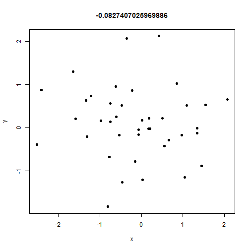

```r
plot(x,y,pch=16,main=cor(x,y))
```

#协方差（covariance）共分散

- 期望值分别为E[X]与E[Y]的两个实随机变量X与Y之间的协方差Cov(X,Y)定义为：

>Cov(X,Y)=E[(X-E[X])(Y-E[Y])]
              =E[XY]-2E[X]E[Y]+E[X]E[Y]
              =E[XY]−E[X]E[Y]

- 样本协方差：

`$$Cov(\left\{ X_{i}\right\} _{i=1},\left\{ Y_{i}\right\} _{i=1}^{n})=\frac{1}{n-1}\mathop{\mathord{\mathop{\sum_{i=1}^{n}}(X_{i}-\bar{X})(Y_{i}-\bar{Y})}}$$`

`$$=\frac{1}{n-1}\sum_{i=1}^{n}X_{i}Y_{i}-\bar{X}\bar{Y}$$`

## 用R来计算协方差

```r
x=1:5
y=c(3, 4, 5, 2, 1)
sum((x - mean(x)) * (y - mean(y))) / (length(x) - 1)
```

```
## [1] -1.5
```

```r
cov(x,y)
```

```
## [1] -1.5
```

## 协方差的解释

- 如果两个变量的变化趋势一致，也就是说如果其中一个大于自身的期望值时另外一个也大于自身的期望值，那么两个变量之间的协方差就是正值；如果两个变量的变化趋势相反，即其中一个变量大于自身的期望值时另外一个却小于自身的期望值，那么两个变量之间的协方差就是负值。
- 如果X与Y是统计独立的，那么二者之间的协方差就是0，因为两个独立的随机变量满足E[XY]=E[X]E[Y]。
>但是，反过来并不成立。即如果X与Y的协方差为0，二者并不一定是统计独立的。

# 相关系数（Correlation coefficient ）　相関係数

- 协方差可以告诉我们X，Y是同方向变化还是反方向变化。

- 可是，由于X，Y的值的大小变化时，协方差也会变化，所以通过协方差的大小，我们不知道变数之间联系的强度。

↓需要一个不依赖于变量大小的尺度

##相关系数是一个不依赖于变量大小，表现俩个变量呈直线关系的程度
比如：都往同一个方向移动的相关系数比较大，没有明确的移动方向的情况，相关系数就比较小。

# 相关系数（Correlation coefficient ）

- 协方差标准化后所得的结果：
`$$\frac{X-E[X]}{\sigma_{X}}$$`
`$$\frac{Y-E[Y]}{\sigma_{Y}}$$`
⇒
`$$Cor(X,Y)=Cor(\frac{X-E[X]}{\sigma_{X}},\frac{Y-E[Y]}{\sigma_{Y}})=\frac{Cov(X,Y)}{\sigma_{X}\sigma_{Y}}=\rho$$`

>σ→标准差

# 相关系数（Correlation coefficient ）

- 样本的相关系数定义：

`$$r=\frac{1}{n-1}\mathop{\sum_{i=1}^{n}\frac{X_{i}-\bar{X}}{S_{X}}}\frac{Y_{i}-\bar{Y}}{S_{Y}}$$`

## 用R来计算相关系数

```r
cov(x, y) / sd(x) / sd(y)
```

```
## [1] -0.6
```

```r
cor(x,y)
```

```
## [1] -0.6
```

# 相关系数（Correlation coefficient ）

- 又称Pearson相关系数

- 注意点

(1)−1≤ρ≤1。ρ接近于1，表示X与Y有正向的相关；ρ接近于-1，表示X与Y有负向的相关。

(2)相关系数只代表的是线性相关性，对于X与Y的其他相关可能反映不出来。
 例如：X~N(0,1),$$Y=X^{2}$$
　→ρ(X,Y)=0

(3)如果散布图是水平或者垂直排列的情况下，相关系数接近于0.

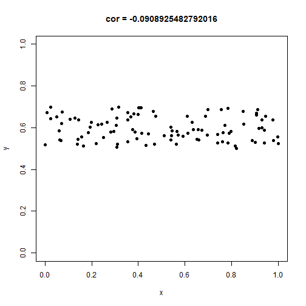

```r
x = runif(100)
y = 0.5 + 0.2 * runif(100)
plot(x, y, pch = 16, main=paste("cor =", cor(x,y)), ylim=c(0,1))
```

(4)倾斜程度与相关系数的大小没有关系。重要的是是否接近于直线。

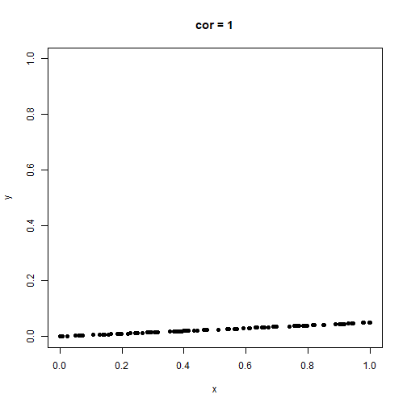

```r
y = 0.05 * x
plot(x, y, pch = 16, main=paste("cor =", cor(x,y)), ylim=c(0,1))
```

(5)相关与因果
- 相关系数是从数据中得到的X和Y两个变量关系的一种描述，不能直接引申为因果关系。
 - 例如，增加身高，不一定增长体重。

- 实际中有许多错误理解相关与因果性的例子。 例如：研究发现喝咖啡的人群比不喝咖啡的人群心脏病发病率高。 于是断言喝咖啡导致心脏病危险增加。 进一步研究更多的因素发现， 喝咖啡放糖很多的人心脏病发病率才增高了。

# 相关系数（Correlation coefficient )

##相关系数大小
- 相关系数绝对值在0.8以上认为高度相关。

- 在0.5到0.8之间认为中度相关。

- 在0.3到0.5之间认为低度相关。

- 在0.3以下认为不相关或相关性很弱以至于没有实际价值。

- 当然，在特别重要的问题中，只要经过检验显著不等于零的相关都认为是有意义的。

# 相关系数的检验

- 相关系数r是总体相关系数ρ的估计。
`$$H_{0}:\rho=0;H_{1}:\rho\neq0$$`

- 检验统计量
`$$t=\frac{r\sqrt{n-2}}{\sqrt{1-r^{2}}}$$`

- 在R中用cor.test(x,y)计算检验。

# 相关系数的检定

##演习

```r
n = 40; a = rnorm(n);b = rnorm(n); c = rnorm(n)
x = a + c
y = b + c
cor.test(x,y)
```

```
##
## 	Pearson's product-moment correlation
##
## data:  x and y
## t = 2.9486, df = 38, p-value = 0.005435
## alternative hypothesis: true correlation is not equal to 0
## 95 percent confidence interval:
##  0.1386238 0.6549705
## sample estimates:
##       cor
## 0.4314998
```

```r
(t <- cor(x, y) * sqrt(n-2) / sqrt(1 - cor(x, y)^2))   #t
```

```
## [1] 2.94857
```

```r
2 * pt(-abs(t), df = n - 2)     #p-value
```

```
## [1] 0.005435247
```

```r
(ci <- t + qt(c(0.025, 0.975), df = n - 2))  #95%CI
```

```
## [1] 0.924176 4.972964
```

```r
ci / sqrt(n - 2 + ci ^ 2)
```

```
## [1] 0.1482642 0.6278796
```

# Pearson相关系数的缺点

## 容易受到偏值的影响。

- 实验

```r
x = rnorm(50)
y1 = x + 0.5 * runif(50)
cor(x, y1)
```

```
## [1] 0.9892352
```

```r
y2 <- y1; y2[5] <- y1[5] + 15
cor(x, y2)
```

```
## [1] 0.2940416
```

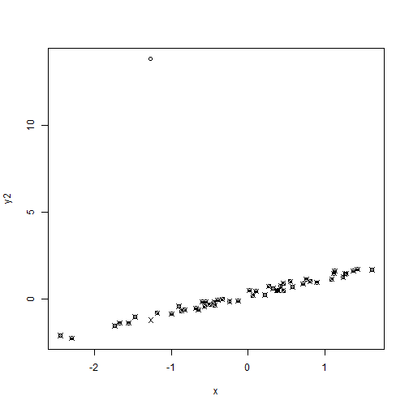

```r
plot(x, y2)
points(x, y1, pch=4)
```

## 解决方法

「Rで楽しむ統計」＆8.4

1.Spearman`s rank correlation coefficient

斯皮尔曼等级相关

>cor.test(...,method="spearman")

2.Kendall`s rank correlation coefficient

肯德尔等级相关

>cor.test(...,method="kendall")

```r
cor(x, y1, method = "kendall")
```

```
## [1] 0.9069388
```

```r
cor(x, y2, method = "kendall")
```

```
## [1] 0.8383673
```

# 三种检定的比较

##Pearson

```r
cor.test(x, y2)
```

```
##
## 	Pearson's product-moment correlation
##
## data:  x and y2
## t = 2.1314, df = 48, p-value = 0.0382
## alternative hypothesis: true correlation is not equal to 0
## 95 percent confidence interval:
##  0.01709288 0.52908587
## sample estimates:
##       cor
## 0.2940416
```

##Spearman

```r
cor.test(x, y2, method = "spearman")
```

```
##
## 	Spearman's rank correlation rho
##
## data:  x and y2
## S = 2198, p-value < 2.2e-16
## alternative hypothesis: true rho is not equal to 0
## sample estimates:
##       rho
## 0.8944538
```

##Kendall

```r
cor.test(x, y2, method = "kendall")
```

```
##
## 	Kendall's rank correlation tau
##
## data:  x and y2
## z = 8.5907, p-value < 2.2e-16
## alternative hypothesis: true tau is not equal to 0
## sample estimates:
##       tau
## 0.8383673
```

# 问题练习

「Rで楽しむ統計」＆8.5

- 日教組組織率と学力の関係
 - 朝日新聞の検証（負の相関はないという説）
 - 産経新聞の検証（負の相関があるという説）

```r
df <- read.csv("https://git.io/fjwcr", fileEncoding = "UTF-8")
View(df)
```

参照p122，除以有效投票数再进行检定。

```r
df$nikkyoso = (df$H16参院選那谷屋正義/df$H16有効投票数 + df$H19参院選神本みえ子 / df$H19有効投票数)
cor.test(df$総合点,df$nikkyoso)
```

```
##
## 	Pearson's product-moment correlation
##
## data:  df$総合点 and df$nikkyoso
## t = -0.25537, df = 45, p-value = 0.7996
## alternative hypothesis: true correlation is not equal to 0
## 95 percent confidence interval:
##  -0.3216928  0.2518782
## sample estimates:
##         cor
## -0.03804014
```

```r
cor.test(df$総合点,df$nikkyoso, method = "pearson")
```

```
##
## 	Pearson's product-moment correlation
##
## data:  df$総合点 and df$nikkyoso
## t = -0.25537, df = 45, p-value = 0.7996
## alternative hypothesis: true correlation is not equal to 0
## 95 percent confidence interval:
##  -0.3216928  0.2518782
## sample estimates:
##         cor
## -0.03804014
```

# 假性相关spurious correlation

- 两变项间本无关系，只因第三变项存在而造成两变项的假相关。例如小学生的平均身高虽与其平均书写词汇间有相关关系。事实上两者间彼此无关，造成其相关的是第三个变项（年龄或年级）。

- 但是，如果两变项之间的相关不是直接的，而是由于两变项间所存在的第三个中介变项使然，这种情况称为间接相关，而非假性相关。例如某公司调查发现已婚员工平均子女数与其定期内平均请假缺席时数具有正相关关系。原因是构成员工缺席的原因与他们子女多需要照顾有关。

-独立的俩个时系列变数 （或者说自己相关很强的俩个变数）之间出现的相关性称为假性相关。
比如说：日本每年的电视机的台数与那一年的平均寿命之间的相关系数非常大，从统计上是有意的。但实际上是因为拥有电视机的台数以及平均寿命都有时间有很强的关系。

```r
cor(cumsum(rnorm(200)), cumsum(rnorm(200)))  #cumsum  自己相関が強い場合
```

```
## [1] 0.2332976
```

>cumsum → 累加和

```r
cumsum(1:5)
```

```
## [1]  1  3  6 10 15
```

```r
cumsum(3:18)
```

```
##  [1]   3   7  12  18  25  33  42  52  63  75  88 102 117 133 150 168
```